# TP 4 : Transformation de variables, imputation et data leakage

Compléments de Mathématiques 2 - L3 MIASHS

Auteur·rice

Lola Etiévant

Date de publication

2026

# Introduction

L’objectif de ce TP est d’approfondir les étapes de préparation des données (*preprocessing*). Nous allons mettre en œuvre des techniques d’imputation pour les données manquantes, explorer les transformations de variables et aborder le concept critique de **Data Leakage** pour garantir l’intégrité de nos futurs modèles.

```r
library(caret)
library(ggplot2)
library(dplyr)

# Chargement des données (ajuster les chemins si nécessaire)
qualitative_vars  <- read.csv("../TP2/titanic_pre_processed_qualitative_vars.csv", stringsAsFactors = TRUE)
quantitative_vars <- read.csv("../TP2/titanic_pre_processed_quantitative_vars.csv")
target            <- read.csv("../TP2/titanic_pre_processed_target.csv")

# Correction des types
qualitative_vars$Pclass  <- as.factor(qualitative_vars$Pclass)
qualitative_vars$withFam <- as.factor(qualitative_vars$withFam)
target                   <- as.factor(target$x)

# Création d'une copie pour les versions complétées
quantitative_vars_complete <- quantitative_vars
```

# Gestion des données manquantes

## Imputation Statique

L’imputation remplace les valeurs manquantes (`NA`) par des statistiques descriptives simples.

### Variable Quantitative (Médiane)

On utilise la médiane plutôt que la moyenne car elle est moins sensible aux valeurs extrêmes.

```r
Proc_median <- preProcess(quantitative_vars, method = "medianImpute")
quantitative_vars_complete <- predict(Proc_median, quantitative_vars)
names(quantitative_vars_complete)[1] <- "Age_imput_median"
```

### Variable Qualitative (Mode)

Pour les catégories, on remplace par la modalité la plus fréquente.

```r
cat_imputation <- function(v) {
  mode_val <- levels(v)[which.max(table(v))]
  v[is.na(v)] <- mode_val
  return(v)
}

qualitative_vars_complete <- qualitative_vars
qualitative_vars_complete$Sex <- cat_imputation(qualitative_vars$Sex)
qualitative_vars_complete$Age_cat <- cat_imputation(qualitative_vars$Age_cat)
```

## Imputation prédictive par régression linéaire

L’imputation prédictive traite la variable manquante comme une cible à prédire à partir des autres informations disponibles.

**NoteConcept**

Peut-on imputer `Age` et `Sex` avec cette méthode ? **Réponse :** Oui pour l’`Age` (variable continue), mais pour `Sex` (binaire), une régression linéaire n’est pas adaptée ; on préférera une régression logistique.

```r
# 1. Identification des indices
isMissing = which(is.na(quantitative_vars$Age))
isNotMissing = which(!is.na(quantitative_vars$Age))

# 2. Préparation des données pour le modèle (Variables Fam et Fare)
age_isNotMissing  = quantitative_vars$Age[isNotMissing]
X_isNotMissing    = quantitative_vars[isNotMissing, c("Fam", "Fare")]
X_isMissing       = quantitative_vars[isMissing, c("Fam", "Fare")]

# 3. Entraînement et prédiction
fit = lm(age_isNotMissing ~ ., data = X_isNotMissing)

quantitative_vars_complete$Age_imput_reg = quantitative_vars$Age
quantitative_vars_complete$Age_imput_reg[isMissing] = predict(fit, X_isMissing)
```

### Visualisation pédagogique

Le graphique suivant montre comment les valeurs imputées (en rouge) s’insèrent dans la distribution existante selon le modèle de régression.

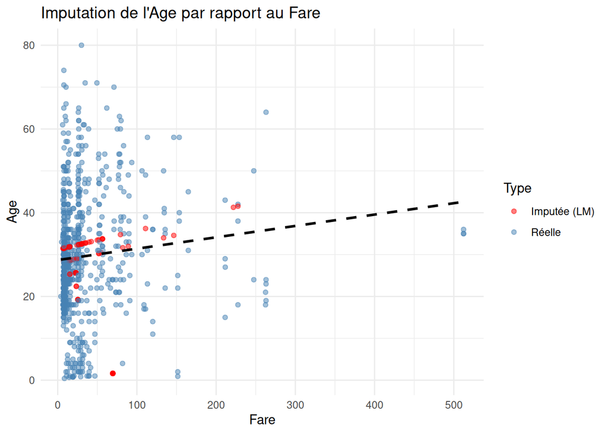

Figure 1: Distribution de l’Age : Valeurs Réelles vs Imputées par Régression

```r
plot_df <- data.frame(
  Fare = quantitative_vars$Fare,
  Age = quantitative_vars_complete$Age_imput_reg,
  Type = ifelse(is.na(quantitative_vars$Age), "Imputée (LM)", "Réelle")
)

ggplot(plot_df, aes(x = Fare, y = Age, color = Type)) +
  geom_point(alpha = 0.5) +
  geom_smooth(data = filter(plot_df, Type == "Réelle"), method = "lm", se = FALSE, color = "black", linetype = "dashed") +
  scale_color_manual(values = c("Imputée (LM)" = "red", "Réelle" = "steelblue")) +
  theme_minimal() +
  labs(title = "Imputation de l'Age par rapport au Fare")
```

# Transformations de variables

## Encodage (Dummy vs Label)

- **Dummy Coding** : Utile pour les variables nominales sans ordre (ex: Sex).
- **Label Encoding** : Réservé aux variables ordinales (ex: Pclass).

## Mise à l’échelle (Scaling)

Il est crucial de ramener les variables à la même échelle pour les algorithmes calculant des distances (comme k-NN).

# Data Leakage

**ImportantDéfinition**

Le **Data Leakage** se produit lorsque des informations du jeu de test sont utilisées lors de l’entraînement. Pour l’éviter, on doit “apprendre” les transformations (moyenne, médiane, etc.) uniquement sur le **Train**.

```r
set.seed(1234)
split <- createDataPartition(target, p = 0.8, list = FALSE)

train_X <- quantitative_vars[split, ]
test_X  <- quantitative_vars[-split, ]

# On calcule les paramètres sur Train
Proc <- preProcess(train_X, method = c("medianImpute", "center", "scale"))

# On applique au Train ET au Test
train_final <- predict(Proc, train_X)
test_final  <- predict(Proc, test_X)
```

# Résumé des étapes

Avant d’appliquer un classifieur :

1. **Split** : Séparer en Train et Test.
2. **Imputation** : Gérer les `NA` (en utilisant les stats du Train).
3. **Transformation** : Encodage et Standardisation (en utilisant les paramètres du Train).